# R Notebook

#Team members: Bhagya,Manisha,Nikki

# Project: Prediction of Cardiovascular Stroke

# Problem: Which age groups and genders are more prone to heart stroke?

# Data Description

#Male : 0 = Female; 1 = Male #age: age at exam time. #education: 1 = Some High School; 2 = High School or GED; 3 = Some College or Vocational School; 4 =college #currentSmoker0 = nonsmoker; 1 = smoker #cigsPerDay: number of cigarettes smoked per day (estimated average) #BPMeds0 = Not on Blood Pressure medications; 1 = Is on Blood Pressure medications #prevalentStroke #prevalentHyp #diabetes: 0 = No; 1 = Yes #totChol-mg/dL #sysBP-mmHg #diaBP-mmHg #BMI: Body Mass Index calculated as: Weight (kg) / Height(meter-squared) #heartRate-Beats/Min (Ventricular) #glucose-mg/dL #TenYearCHD

# Install libraries

```r
#install.packages("readr)
#install.packages("caret)
#install.packages("corrplot)
#install.packages("class)
#install.packages("rpart)
#install.packages("e1071)
#install.packages("ROCR")
#install.packages("pROC)
#install.packages("tidyverse)
#install.packages(cluster)
#install.packages("factoextra")
#install.packages("ISLR)
#install.packages("caTools")
#install.packages("RMySQL")
#install.packages("gridExtra")
#install.packages("PerformanceAnalytics")
#install.packages("arules")
#install.packages("arulesViz")
```

# Load libraries

```r
library(readr)
library(caret)
library(corrplot)
library(class)
library(rpart)
library(rpart.plot)
library(party)
library(e1071)
library(ROCR)
library(pROC)
library(tidyverse)  # data manipulation
library(cluster)    # clustering algorithms
library(factoextra) # clustering algorithms & visualization
library(ISLR)
library(caTools)
library(RMySQL)
library(gridExtra)
library(PerformanceAnalytics)
```

# connect from AWS database

```r
con <- dbConnect(MySQL(),
                             user = 'bigdata',
                             password = 'Best2019',
                             dbname = 'bigdata',
                             host = 'bigdata.cuvl8scby0ib.us-east-1.rds.amazonaws.com',
                             port = 3306)
```

# Import the data

```r
# send the query

df <- dbSendQuery(con,"SELECT * FROM cvdata")
#fecth() converts the query results (stored on the server) to a local data frame
diseases<- fetch(df, n = -1)
summary(diseases)
```

```
      sex              age          education    currentSmoker      cigsPerDay
 Min.   :0.0000   Min.   :32.00   Min.   :1.00   Min.   :0.0000   Min.   : 0.000
 1st Qu.:0.0000   1st Qu.:42.00   1st Qu.:1.00   1st Qu.:0.0000   1st Qu.: 0.000
 Median :0.0000   Median :49.00   Median :2.00   Median :0.0000   Median : 0.000
 Mean   :0.4437   Mean   :49.56   Mean   :1.98   Mean   :0.4891   Mean   : 9.022
 3rd Qu.:1.0000   3rd Qu.:56.00   3rd Qu.:3.00   3rd Qu.:1.0000   3rd Qu.:20.000
 Max.   :1.0000   Max.   :70.00   Max.   :4.00   Max.   :1.0000   Max.   :70.000
     BPMeds        prevalentStroke     prevalentHyp       diabetes          totChol
 Min.   :0.00000   Min.   :0.000000   Min.   :0.0000   Min.   :0.00000   Min.   :113.0
 1st Qu.:0.00000   1st Qu.:0.000000   1st Qu.:0.0000   1st Qu.:0.00000   1st Qu.:206.0
 Median :0.00000   Median :0.000000   Median :0.0000   Median :0.00000   Median :234.0
 Mean   :0.03036   Mean   :0.005744   Mean   :0.3115   Mean   :0.02708   Mean   :236.9
 3rd Qu.:0.00000   3rd Qu.:0.000000   3rd Qu.:1.0000   3rd Qu.:0.00000   3rd Qu.:263.2
 Max.   :1.00000   Max.   :1.000000   Max.   :1.0000   Max.   :1.00000   Max.   :600.0
     sysBP           diaBP             BMI          heartRate         glucose
 Min.   : 84.0   Min.   : 48.00   Min.   :16.00   Min.   : 44.00   Min.   : 40.00
 1st Qu.:117.0   1st Qu.: 75.00   1st Qu.:23.00   1st Qu.: 68.00   1st Qu.: 71.00
 Median :128.0   Median : 82.00   Median :25.00   Median : 75.00   Median : 78.00
 Mean   :132.5   Mean   : 82.99   Mean   :25.79   Mean   : 75.73   Mean   : 81.86
 3rd Qu.:144.0   3rd Qu.: 90.00   3rd Qu.:28.00   3rd Qu.: 82.00   3rd Qu.: 87.00
 Max.   :295.0   Max.   :143.00   Max.   :57.00   Max.   :143.00   Max.   :394.00
   TenYearCHD       Diseases
 Min.   :0.0000   Length:3656
 1st Qu.:0.0000   Class :character
 Median :0.0000   Mode  :character
 Mean   :0.1524
 3rd Qu.:0.0000
 Max.   :1.0000
```

```r
print(diseases)
```

| sex | age | education | currentSmoker | cigsPerDay | BPMeds | prevalentStroke | prevalentHyp | diabetes | totChol | sysBP | diaBP | BMI | heartRate | glucose | TenYearCHD | Diseases |
| --- | --- | --- | --- | --- | --- | --- | --- | --- | --- | --- | --- | --- | --- | --- | --- | --- |
| 0 | 66 | 1 | 0 | 0 | 0 | 0 | 1 | 0 | 214 | 212 | 104 | 25 | 57 | 84 | 1 | Aortic Aneurysm\r |
| 0 | 46 | 3 | 0 | 0 | 0 | 0 | 1 | 0 | 237 | 196 | 120 | 32 | 58 | 60 | 1 | Aortic Aneurysm\r |
| 0 | 57 | 1 | 0 | 0 | 0 | 0 | 1 | 0 | 233 | 184 | 106 | 39 | 66 | 40 | 1 | Aortic Aneurysm\r |
| 1 | 59 | 1 | 1 | 3 | 0 | 0 | 1 | 1 | 230 | 182 | 102 | 26 | 66 | 147 | 1 | Aortic Aneurysm\r |
| 0 | 48 | 2 | 0 | 0 | 0 | 0 | 1 | 0 | 224 | 193 | 115 | 23 | 67 | 85 | 1 | Aortic Aneurysm\r |
| 0 | 64 | 1 | 0 | 0 | 0 | 0 | 1 | 0 | 194 | 176 | 97 | 33 | 68 | 89 | 1 | Aortic Aneurysm\r |
| 1 | 40 | 1 | 0 | 0 | 0 | 0 | 1 | 0 | 175 | 173 | 59 | 28 | 70 | 75 | 1 | Aortic Aneurysm\r |
| 1 | 57 | 1 | 1 | 3 | 0 | 0 | 1 | 0 | 225 | 178 | 120 | 25 | 72 | 96 | 1 | Aortic Aneurysm\r |
| 1 | 48 | 2 | 1 | 17 | 0 | 0 | 1 | 0 | 250 | 177 | 124 | 26 | 75 | 69 | 1 | Aortic Aneurysm\r |
| 0 | 62 | 1 | 0 | 0 | 1 | 0 | 1 | 0 | 186 | 177 | 92 | 23 | 79 | 60 | 1 | Aortic Aneurysm\r |

[output cut: 990 more lines]

# Rename the datafile

```r
framingham_heart_disease <- diseases
```

# Remove missing values

```r
framingham_heart_disease <- drop_na(framingham_heart_disease)
print(framingham_heart_disease)
```

|  | sex | age | education | currentSmoker | cigsPerDay | BPMeds | prevalentStroke | prevalentHyp | diabetes | totChol | sysBP | diaBP | BMI | heartRate | glucose | TenYearCHD | Diseases |
| --- | --- | --- | --- | --- | --- | --- | --- | --- | --- | --- | --- | --- | --- | --- | --- | --- | --- |
| 1 | 0 | 66 | 1 | 0 | 0 | 0 | 0 | 1 | 0 | 214 | 212 | 104 | 25 | 57 | 84 | 1 | Aortic Aneurysm\r |
| 2 | 0 | 46 | 3 | 0 | 0 | 0 | 0 | 1 | 0 | 237 | 196 | 120 | 32 | 58 | 60 | 1 | Aortic Aneurysm\r |
| 3 | 0 | 57 | 1 | 0 | 0 | 0 | 0 | 1 | 0 | 233 | 184 | 106 | 39 | 66 | 40 | 1 | Aortic Aneurysm\r |
| 4 | 1 | 59 | 1 | 1 | 3 | 0 | 0 | 1 | 1 | 230 | 182 | 102 | 26 | 66 | 147 | 1 | Aortic Aneurysm\r |
| 5 | 0 | 48 | 2 | 0 | 0 | 0 | 0 | 1 | 0 | 224 | 193 | 115 | 23 | 67 | 85 | 1 | Aortic Aneurysm\r |
| 6 | 0 | 64 | 1 | 0 | 0 | 0 | 0 | 1 | 0 | 194 | 176 | 97 | 33 | 68 | 89 | 1 | Aortic Aneurysm\r |
| 7 | 1 | 40 | 1 | 0 | 0 | 0 | 0 | 1 | 0 | 175 | 173 | 59 | 28 | 70 | 75 | 1 | Aortic Aneurysm\r |
| 8 | 1 | 57 | 1 | 1 | 3 | 0 | 0 | 1 | 0 | 225 | 178 | 120 | 25 | 72 | 96 | 1 | Aortic Aneurysm\r |
| 9 | 1 | 48 | 2 | 1 | 17 | 0 | 0 | 1 | 0 | 250 | 177 | 124 | 26 | 75 | 69 | 1 | Aortic Aneurysm\r |
| 10 | 0 | 62 | 1 | 0 | 0 | 1 | 0 | 1 | 0 | 186 | 177 | 92 | 23 | 79 | 60 | 1 | Aortic Aneurysm\r |

[output cut: 990 more lines]

# Correlation

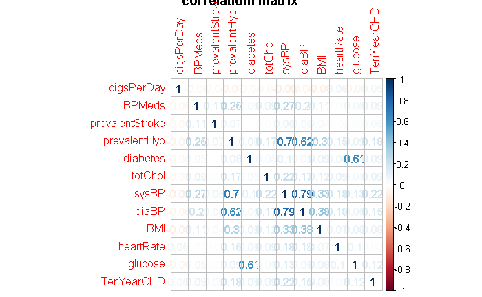

```r
corrr <-cor(framingham_heart_disease[5:16])
corrplot(corrr ,method="number",main = "correlatiom matrix")
```

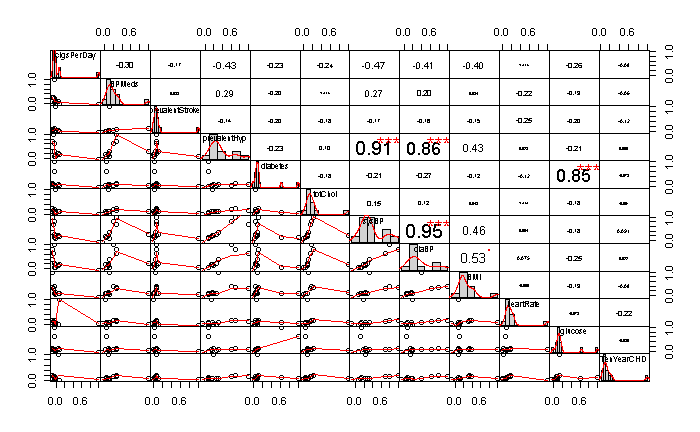

```r
library(PerformanceAnalytics)
chart.Correlation(corrr, histogram = TRUE, pch = 19)
```

# Changing numbers to male and female

```r
framingham_heart_disease$sex[framingham_heart_disease$sex== 1] = "Male"
framingham_heart_disease$sex[framingham_heart_disease$sex== 0] = "Female"
```

# Exploratory Analysis

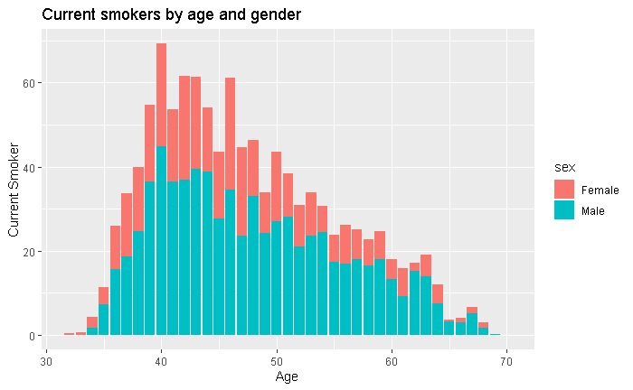

```r
framingham_heart_disease$sex <-as.factor(framingham_heart_disease$sex)
ggplot(framingham_heart_disease,aes(x=age,y=cigsPerDay/30))+
         geom_bar(aes(fill=sex),stat="identity")+
            labs(x="Age",y="Current Smoker",title="Current smokers by age and gender")
```

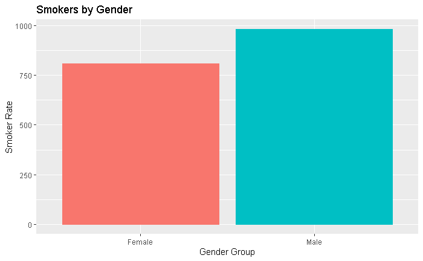

```r
ggplot(data = framingham_heart_disease, mapping = aes(x = as.factor(sex), y = currentSmoker,color = sex) ) + geom_bar(stat = "identity") +
    labs(x = "Gender Group", y = "Smoker Rate", title = "Smokers by Gender") + theme(legend.position="none")
```

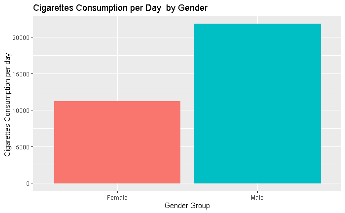

```r
ggplot(data = framingham_heart_disease, mapping = aes(x = sex, y = cigsPerDay, color = sex)) + geom_bar(stat = "identity") +
    labs(x = "Gender Group", y = "Cigarettes Consumption per day ", title = "Cigarettes Consumption per Day  by Gender")  +  theme(legend.position="none")
```

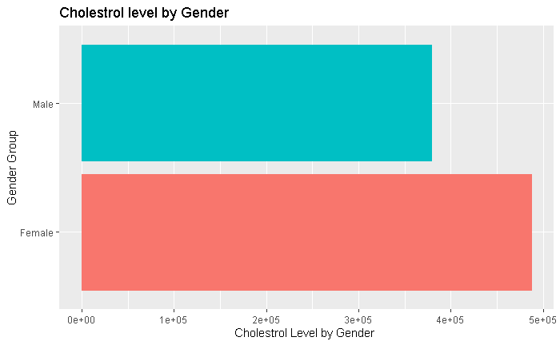

```r
ggplot(data = framingham_heart_disease, mapping = aes(x = sex, y = totChol, color = sex)) +
  coord_flip()+ geom_bar(stat = "identity") + labs(x = "Gender Group", y = "Cholestrol Level by Gender ",
      title = "Cholestrol level by Gender")+  theme(legend.position="none")
```

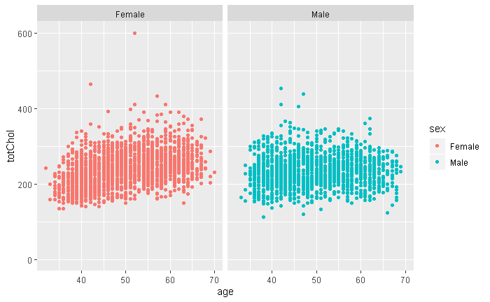

```r
ggplot(framingham_heart_disease,aes(x=age,y=totChol,color=sex))+geom_point()+facet_wrap(~sex)+
  scale_y_continuous(limits=c(0,600))
```

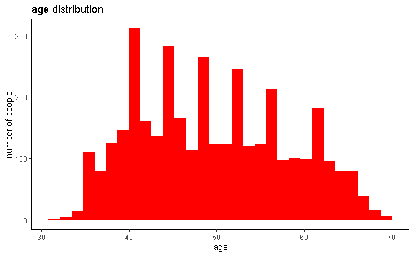

```r
ggplot(framingham_heart_disease,aes(x = age)) + geom_histogram(bins =30,fill ="red") +
  theme_bw() + theme_classic() +labs(title="age distribution",y="number of people")
```

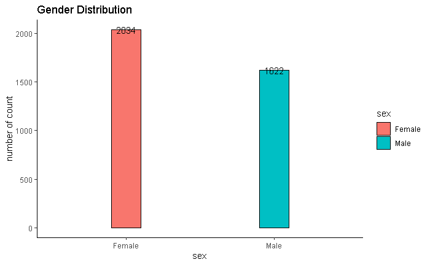

```r
ggplot(framingham_heart_disease,aes(x =sex, fill=sex)) + geom_bar(width = 0.2, color='black') + geom_text(stat = 'count',aes(label =..count..)) + theme_bw() + theme_classic() +labs(y="number of count",title="Gender Distribution")
```

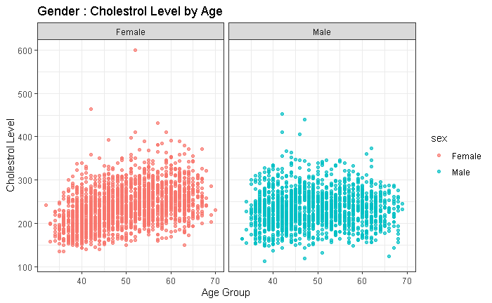

```r
ggplot(framingham_heart_disease,aes(x=age,y=totChol, color = sex))+geom_point(alpha=0.7)+facet_grid(~sex)+theme(legend.position="none")+
  labs(title = "Gender : Cholestrol Level by Age ", x = "Age Group",
                                            y = "Cholestrol Level") + theme_bw()
```

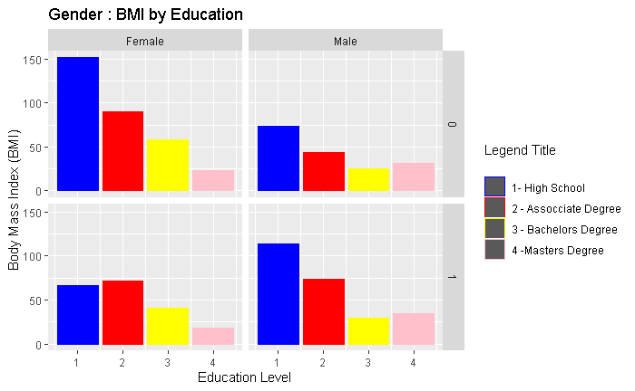

```r
ggplot(framingham_heart_disease,aes(x=education,y=BMI/100,color = as.factor(framingham_heart_disease$education)))+geom_bar(stat="identity")+
  labs(title = "Temperatures\n", x = "TY [°C]", y = "Txxx", color = "Legend Title\n") +
  scale_color_manual(labels = c("1- High School", "2 - Assocciate Degree","3 - Bachelors Degree","4 -Masters Degree"), values = c("blue",   "red","yellow","pink")) +
  facet_grid(currentSmoker~sex) + labs(title = "Gender : BMI by Education ", x = "Education Level", y = "Body Mass Index (BMI)")
```

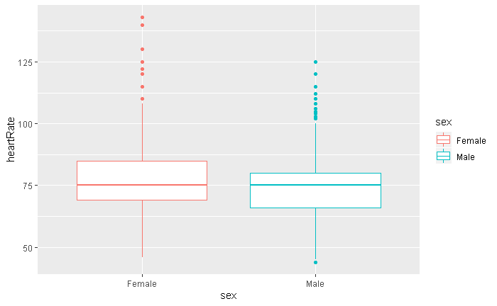

```r
ggplot(framingham_heart_disease,aes(x=sex,y=heartRate,color=sex))+geom_boxplot()
```

```r
NA
```

#cluster Analysis #Hierarchical clustering can’t handle big data well but K Means clustering can. This is because the time complexity of K Means is linear i.e. O(n) while that of hierarchical clustering is quadratic i.e. O(n2). #k-means clustering #given 3 clusters by age group

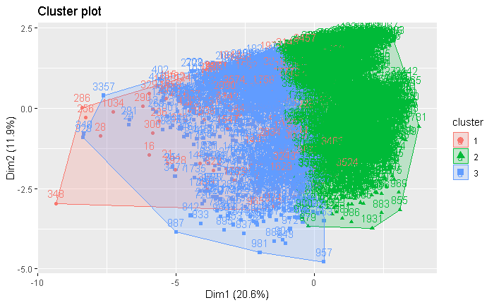

```r
set.seed(20)
data <- diseases
df <- scale(data[,-17])
k2 <- kmeans(df, centers = 3, nstart = 25)
fviz_cluster(k2, data = df)
```

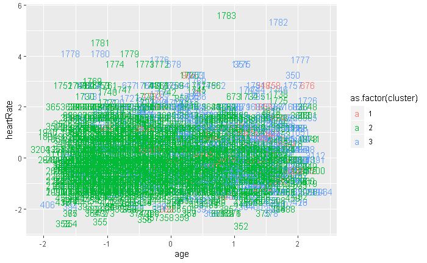

```r
df %>%
  as_tibble() %>%
  mutate(cluster = k2$cluster,
         ages = row.names(framingham_heart_disease)) %>%
  ggplot(aes(x= age, y= heartRate,color = as.factor(cluster), label = ages)) +
  geom_text()
```

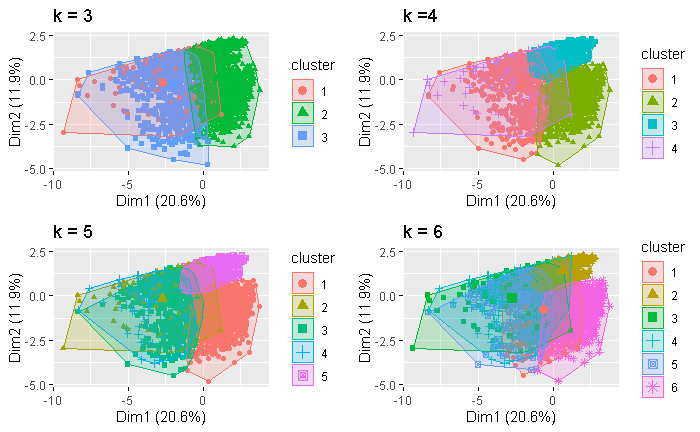

```r
# checking cluster for 4,5,6 and visualizing
k3 <- kmeans(df, centers = 4, nstart = 25)
k4 <- kmeans(df, centers = 5, nstart = 25)
k5 <- kmeans(df, centers = 6, nstart = 25)

# plots to compare
p1 <- fviz_cluster(k2, geom = "point", data = df) + ggtitle("k = 3")
p2 <- fviz_cluster(k3, geom = "point",  data = df) + ggtitle("k =4")
p3 <- fviz_cluster(k4, geom = "point",  data = df) + ggtitle("k = 5")
p4 <- fviz_cluster(k5, geom = "point",  data = df) + ggtitle("k = 6")


grid.arrange(p1, p2, p3, p4, nrow = 2)
```

#Determining Optimal Clusters

```r
set.seed(123)

# function to compute total within-cluster sum of square
wss <- function(k) {
  kmeans(df, k, nstart = 25 )$tot.withinss
}

# Compute and plot wss for k = 1 to k = 15
k.values <- 1:15

# extract wss for 2-15 clusters
wss_values <- map_dbl(k.values, wss)
```

```
did not converge in 10 iterations
```

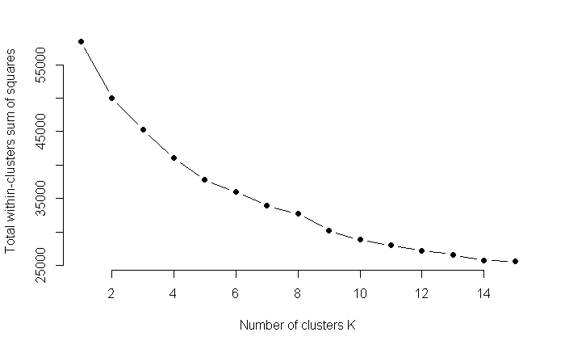

```r
plot(k.values, wss_values,
       type="b", pch = 19, frame = FALSE,
       xlab="Number of clusters K",
       ylab="Total within-clusters sum of squares")
```

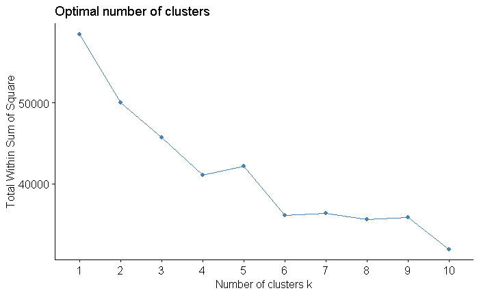

```r
set.seed(123)

fviz_nbclust(df, kmeans, method = "wss")
```

```r
# function to compute average silhouette for k clusters
avg_sil <- function(k) {
  km.res <- kmeans(df, centers = k, nstart = 25)
  ss <- silhouette(km.res$cluster, dist(df))
  mean(ss[, 3])
}

# Compute and plot wss for k = 2 to k = 15
k.values <- 2:15

# extract avg silhouette for 2-15 clusters
avg_sil_values <- map_dbl(k.values, avg_sil)
```

```
did not converge in 10 iterations
```

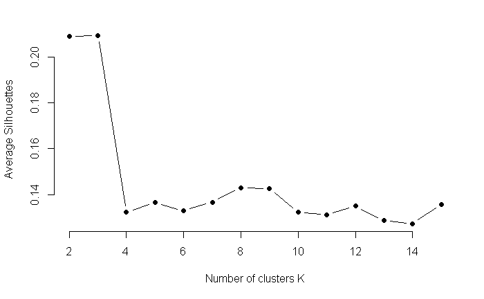

```r
plot(k.values, avg_sil_values,
       type = "b", pch = 19, frame = FALSE,
       xlab = "Number of clusters K",
       ylab = "Average Silhouettes")
```

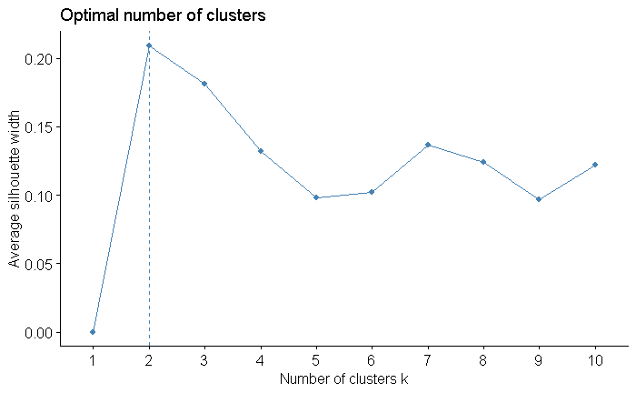

```r
fviz_nbclust(df, kmeans, method = "silhouette")
```

#Backward elimination linear model

```r
bk_lm <- lm(heartRate ~ .,
            data = framingham_heart_disease)
step(bk_lm,direction="backward")
```

```
Start:  AIC=16723.33
heartRate ~ sex + age + education + currentSmoker + cigsPerDay +
    BPMeds + prevalentStroke + prevalentHyp + diabetes + totChol +
    sysBP + diaBP + BMI + glucose + TenYearCHD + Diseases


Step:  AIC=16723.33
heartRate ~ sex + age + education + currentSmoker + cigsPerDay +
    BPMeds + prevalentStroke + prevalentHyp + diabetes + totChol +
    sysBP + diaBP + BMI + glucose + Diseases

                  Df Sum of Sq    RSS   AIC
- currentSmoker    1        14 348701 16722
- diabetes         1        31 348718 16722
- prevalentStroke  1        52 348739 16722
- BMI              1        58 348745 16722
- prevalentHyp     1       116 348803 16723
- sysBP            1       118 348804 16723
<none>                         348687 16723
- education        1       443 349129 16726
- BPMeds           1       560 349247 16727
- totChol          1       727 349414 16729
- age              1       831 349518 16730
- cigsPerDay       1      1283 349970 16735
- glucose          1      1458 350144 16737
- diaBP            1      1900 350587 16741
- sex              1      5785 354472 16782
- Diseases        15    131335 480022 17862

Step:  AIC=16721.48
heartRate ~ sex + age + education + cigsPerDay + BPMeds + prevalentStroke +
    prevalentHyp + diabetes + totChol + sysBP + diaBP + BMI +
    glucose + Diseases

                  Df Sum of Sq    RSS   AIC
- diabetes         1        31 348732 16720
- prevalentStroke  1        51 348752 16720
- BMI              1        63 348764 16720
- prevalentHyp     1       115 348816 16721
- sysBP            1       118 348819 16721
```

[output cut: 116 more lines]

```
                           0.03771                             2.98187
         DiseasesAortic Stenosis\r           DiseasesAtherosclerosis\r
                          -0.10873                             1.73035
             DiseasesBradycardia\r            DiseasesCardiomyopathy\r
                         -19.49384                            -0.92718
                    DiseasesCOPD\r               DiseasesLung Cancer\r
                           0.69296                            -0.81875
            DiseasesLung fibrois\r             DiseasesLung fibrosis\r
                           0.85338                            -2.28462
    DiseasesMitral Regurgitation\r                DiseasesNo disease\r
                           1.47785                             0.30522
            DiseasesPericarditis\r    DiseasesPulmonary hypertension\r
                           0.57203                            -0.89359
             DiseasesTachycardia\r  DiseasesVentricular fibrillation\r
                          34.19678                            -0.25584
```

# Forward Selection

```r
fw_lm <- lm(heartRate ~ .,
            data = framingham_heart_disease)
nullmodel <- lm(heartRate~1, framingham_heart_disease)
step(nullmodel,direction="forward",
     scope = heartRate ~ sex + age + education + currentSmoker + cigsPerDay +
    BPMeds + prevalentStroke + prevalentHyp + diabetes + totChol +
    sysBP + diaBP + BMI + glucose + TenYearCHD + Diseases)
```

```
Start:  AIC=18160.24
heartRate ~ 1

                  Df Sum of Sq    RSS   AIC
+ Diseases        15    158707 366119 16874
+ sysBP            1     17884 506941 18036
+ diaBP            1     16861 507965 18043
+ prevalentHyp     1     11392 513433 18082
+ sex              1      6932 517894 18114
+ glucose          1      4941 519885 18128
+ totChol          1      4545 520281 18130
+ BMI              1      2868 521957 18142
+ education        1      2167 522659 18147
+ cigsPerDay       1      2120 522706 18147
+ diabetes         1      1953 522873 18149
+ currentSmoker    1      1336 523490 18153
<none>                         524826 18160
+ TenYearCHD       1       221 524605 18161
+ prevalentStroke  1       152 524674 18161
+ BPMeds           1        87 524738 18162
+ age              1         4 524822 18162

Step:  AIC=16873.68
heartRate ~ Diseases

                  Df Sum of Sq    RSS   AIC
+ diaBP            1    4850.2 361268 16827
+ sex              1    3874.0 362245 16837
+ sysBP            1    3697.1 362421 16839
+ glucose          1    2572.8 363546 16850
+ cigsPerDay       1    1125.6 364993 16864
+ diabetes         1    1117.4 365001 16865
+ totChol          1     888.0 365231 16867
+ prevalentHyp     1     837.4 365281 16867
+ BMI              1     671.7 365447 16869
+ currentSmoker    1     532.3 365586 16870
+ education        1     521.7 365597 16871
+ age              1     404.3 365714 16872
<none>                         366119 16874
+ prevalentStroke  1      35.8 366083 16875
```

[output cut: 143 more lines]

```
                           0.85338                            -2.28462
    DiseasesMitral Regurgitation\r                DiseasesNo disease\r
                           1.47785                             0.30522
            DiseasesPericarditis\r    DiseasesPulmonary hypertension\r
                           0.57203                            -0.89359
             DiseasesTachycardia\r  DiseasesVentricular fibrillation\r
                          34.19678                            -0.25584
                             diaBP                             sexMale
                           0.13235                            -2.81111
                        cigsPerDay                             glucose
                           0.10736                             0.03771
                           totChol                                 age
                           0.01234                            -0.06695
                         education                              BPMeds
                          -0.37947                            -1.96002
```

#Split the data

```r
set.seed(123)   #  set seed to ensure you always have same random numbers generated
sample = sample.split(framingham_heart_disease$TenYearCHD,SplitRatio = 0.75) # splits the data in the ratio mentioned in SplitRatio. After splitting marks these rows as logical TRUE and the the remaining are marked as logical FALSE
train1 =subset(framingham_heart_disease,sample ==TRUE) # creates a training dataset named train1 with rows which are marked as TRUE
test1=subset(framingham_heart_disease, sample==FALSE)
```

# Linear regression

```r
fit_lm <- lm(heartRate ~ sysBP + sex + cigsPerDay + glucose + diaBP + age +
               totChol + education + BPMeds + prevalentHyp, data=train1)
summary(fit_lm)
```

```
Call:
lm(formula = heartRate ~ sysBP + sex + cigsPerDay + glucose +
    diaBP + age + totChol + education + BPMeds + prevalentHyp,
    data = train1)

Residuals:
    Min      1Q  Median      3Q     Max
-30.156  -7.938  -1.031   6.641  61.064

Coefficients:
              Estimate Std. Error t value Pr(>|t|)
(Intercept)  60.039242   2.606115  23.038  < 2e-16 ***
sysBP         0.054630   0.019173   2.849 0.004413 **
sexMale      -3.293742   0.474474  -6.942 4.82e-12 ***
cigsPerDay    0.135842   0.019838   6.847 9.25e-12 ***
glucose       0.044821   0.008885   5.044 4.85e-07 ***
diaBP         0.104868   0.030834   3.401 0.000681 ***
age          -0.144909   0.029780  -4.866 1.20e-06 ***
totChol       0.019768   0.005270   3.751 0.000180 ***
education    -0.741909   0.218576  -3.394 0.000698 ***
BPMeds       -4.287751   1.306152  -3.283 0.001041 **
prevalentHyp  1.191857   0.676353   1.762 0.078150 .
---
Signif. codes:  0 ‘***’ 0.001 ‘**’ 0.01 ‘*’ 0.05 ‘.’ 0.1 ‘ ’ 1

Residual standard error: 11.48 on 2731 degrees of freedom
Multiple R-squared:  0.08918,   Adjusted R-squared:  0.08584
F-statistic: 26.74 on 10 and 2731 DF,  p-value: < 2.2e-16
```

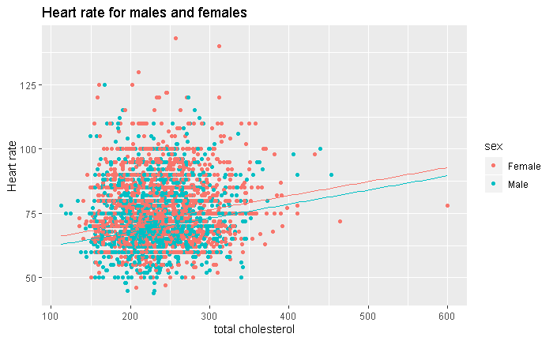

```r
equation1=function(x){
  coef(fit_lm)[2]*x+coef(fit_lm)[1]
  }
equation2=function(x){
  coef(fit_lm)[2]*x+coef(fit_lm)[1]+coef(fit_lm)[3]
  }

ggplot(framingham_heart_disease,aes(y=heartRate,x=totChol,color= sex))+geom_point()+
        stat_function(fun=equation1,geom="line",color=scales::hue_pal()(2)[1])+
        stat_function(fun=equation2,geom="line",color=scales::hue_pal()(2)[2])+labs(x="total cholesterol",y="Heart rate",title = "Heart rate for males and females")
```

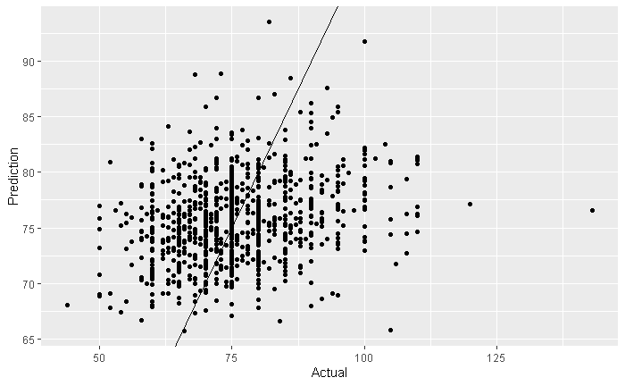

```r
#predict on test data
pred_lm <- predict(fit_lm,test1)
results_lm <- data.frame(Actual =test1$heartRate,Prediction =pred_lm)
ggplot(data= results_lm,aes(x= Actual,y=Prediction))+geom_point()+geom_abline()
```

```r
#predict on new data
newdata <- data.frame(totChol = 650,sysBP= 300, cigsPerDay= 70,glucose = 400,diaBP= 150,
                      sex = "Female",age =50,education =4,BPMeds = 1,prevalentHyp= 1)
 newdata1 <- data.frame(totChol= 650, sysBP= 300,cigsPerDay=70,glucose= 400, diaBP= 150,
                        sex ="Male",age= 50,education=4,BPMeds = 1,prevalentHyp=1)
result <- predict(fit_lm,newdata )
result1 <- predict(fit_lm,newdata1)
cat("The Predicted heartrate for female is" , result,"\n")
```

```
The Predicted heartrate for female is 119.1359
```

```r
cat("The Predicted heartrate for male is" , result1)
```

```
The Predicted heartrate for male is 115.8421
```